# DATA PREPROCESSING WITH R

## 3.8 Multivariate outlier

Ta sử dụng dataset Animals trong gói package MASS. Đây là tập dữ liệu chứa các quan sát về trung bình khối lượng cơ thể - body (đơn vị kg) và khối lượng bộ não (đơn vị gam) các loài động vật

```r
library(MASS)

animals <- Animals
head(animals)
```

```
##                     body brain
## Mountain beaver     1.35   8.1
## Cow               465.00 423.0
## Grey wolf          36.33 119.5
## Goat               27.66 115.0
## Guinea pig          1.04   5.5
## Dipliodocus     11700.00  50.0
```

Ta sử dụng phép logarithmic transformation lên cả 2 biến trên

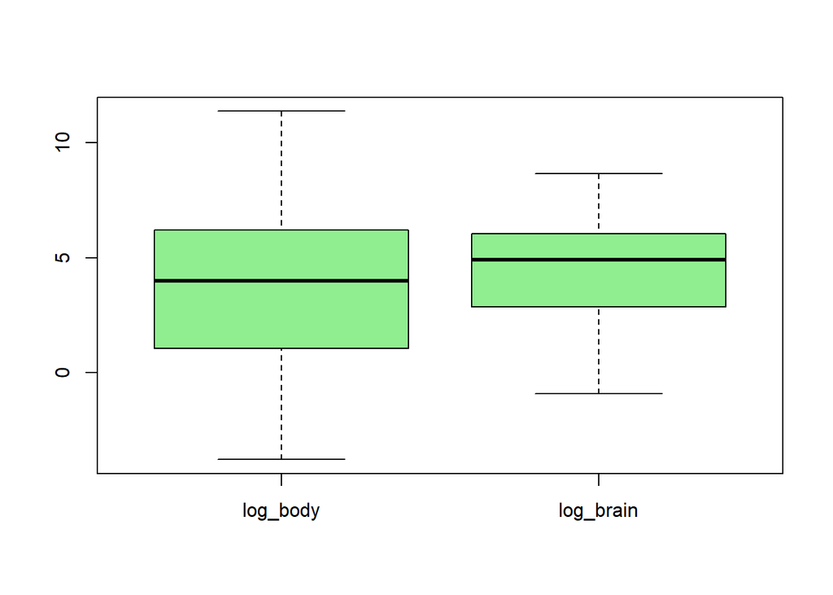

```r
df <- data.frame(log_body = log(animals$body), log_brain = log(animals$brain))
boxplot(df, col='lightgreen')
```

Theo biểu đồ trên ta thấy không xuất hiện các giá trị ngoại lai nào ở từng biến. Tuy nhiên nếu ta vẽ biểu đồ scatter plot, ta sẽ thấy có 3 điểm dữ liệu trông có vẻ chính là multivariate outlier.

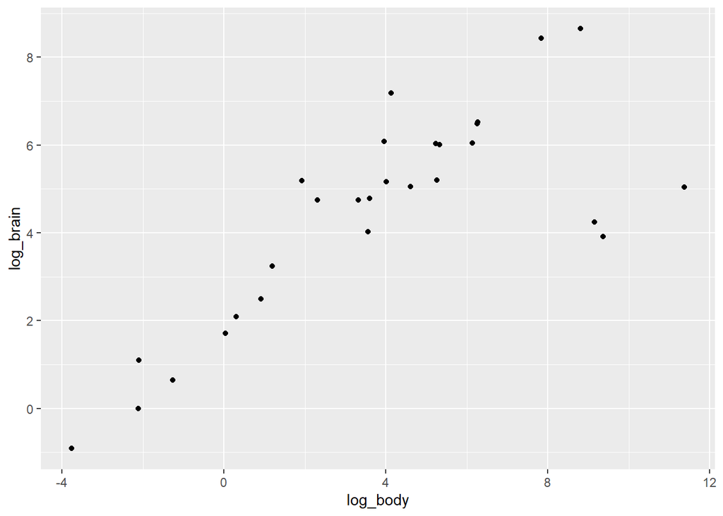

```r
ggplot(df, aes(x=log_body, y=log_brain)) +
  geom_point()
```

**Khoảng cách Mahalanobis** được đề xuất để tìm các multivariate outlier. Mahalanobis được sử dụng cùng với MCD: Minimum Covariance Determinant.  
Ta sẽ sử dụng package **robustbase** để tính MCD

```r
library(robustbase)
animal.mcd <- covMcd(df)
animal.mcd$center
```

```
##  log_body log_brain
##  3.028827  4.275608
```

```r
animal.mcd$cov
```

```
##           log_body log_brain
## log_body  13.02799  9.782350
## log_brain  9.78235  7.622264
```

Kết quả có được hình sau

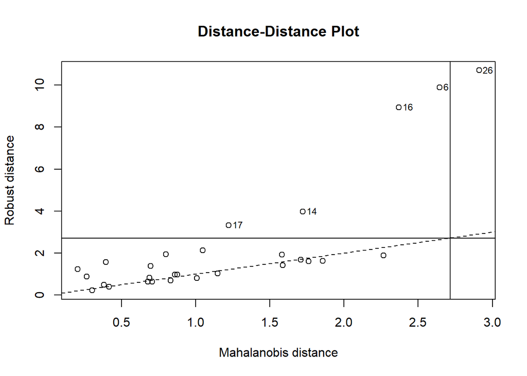

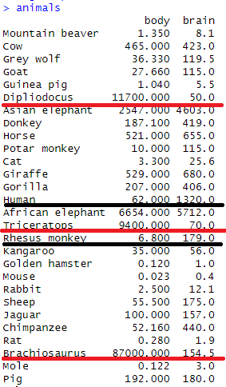

```r
plot(animal.mcd, which='dd')
```

**Lưu ý**: Phương pháp này chỉ thực hiện được giữa 2 biến, việc xác định multivariate outlier ở trên nhiều chiều hơn sẽ có các cách khác để thực hiện.

# 4 OBVIOUS INCONSISTENCIES

## 4.1 Create an inconsistent sample

Manual creating a sample dataset contains obvious inconsistencies:

```r
gen_data <- read.csv('E:\\MSc.Data-Science\\Mo-hinh-hoa-thong-ke\\Project\\Group\\gen_data.csv', header=T)
head(gen_data)
```

```
##   age agegroup height  status yearsmarried
## 1  21    adult    6.0  single           -1
## 2   2    child    3.0 married            0
## 3  18    adult    5.7 married           20
## 4 221  elderly    5.0 widowed            2
## 5  34    child   -7.0 married            3
```

Notify that:

- 0 $<$ age $<$ 150
- height > 0
- agegroup = **‘child’** can not get **‘married’** value in status
- yearsmarried > 0

## 4.2 Step 1

**To fix this we can use the library: editrules**  
Creating a text file named: *edits.txt* containing rules:

- numerical rules:
  - age >= 0
  - age <= 150
  - height > 0
  - age > yearsmarried
- categorical rules:
  - status %in% c(“married”,“single”,“widowed”)
  - agegroup %in% c(“child”,“adult”,“elderly”)
  - if (status == “married”) agegroup %in% c(“adult”,“elderly”)
- mixed rules
  - if ( status %in% c(“married”,“widowed”)) age - yearsmarried >= 18
  - if ( age < 18 ) agegroup == “child”
  - if ( age >= 18 && age <65 ) agegroup == “adult”
  - if ( age >= 65 ) agegroup == “elderly”

## 4.3 Step 2

Using package **editrules** to check:

```r
edit <- editfile("E:/MSc.Data-Science/Mo-hinh-hoa-thong-ke/Project/Group/edits.txt")
edit
```

```
##
## Data model:
## dat5 : agegroup %in% c('adult', 'child', 'elderly')
## dat6 : status %in% c('married', 'single', 'widowed')
##
## Edit set:
## num1 : 0 <= age
## num2 : age <= 150
## num3 : 0 < height
## num4 : yearsmarried < age
## num5 : yearsmarried + 18 <= age
## cat6 : if( agegroup == 'child' ) status != 'married'
## mix7 : if( age < 18 ) !( agegroup %in% c('adult', 'elderly') )
## mix8 : if( 18 <= age & age < 65 ) !( agegroup %in% c('child', 'elderly') )
## mix9 : if( 65 <= age ) !( agegroup %in% c('adult', 'child') )
```

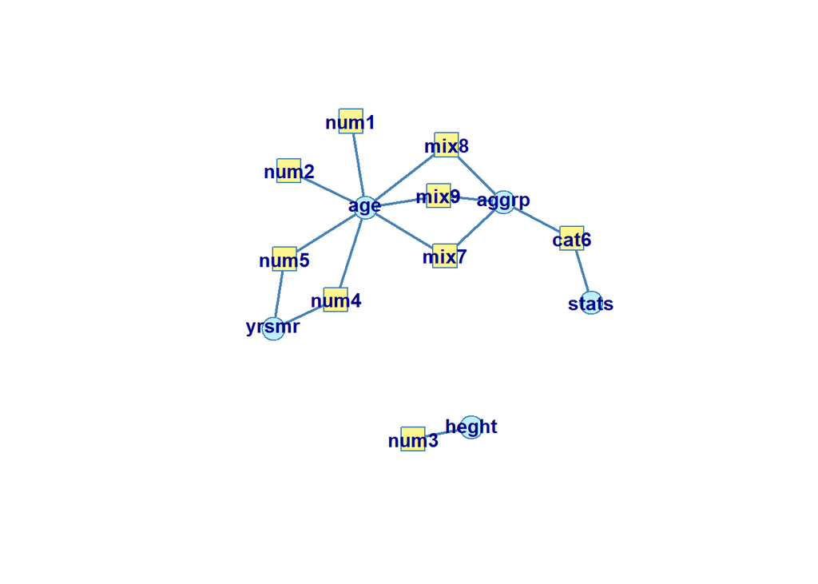

```r
plot(edit)
```

```r
ve <- violatedEdits(edit, gen_data)
print(ve)
```

```
##       edit
## record  num1  num2  num3  num4  num5  dat5  dat6  cat6  mix7  mix8  mix9
##      1 FALSE FALSE FALSE FALSE FALSE FALSE FALSE FALSE FALSE FALSE FALSE
##      2 FALSE FALSE FALSE FALSE  TRUE FALSE FALSE  TRUE FALSE FALSE FALSE
##      3 FALSE FALSE FALSE  TRUE  TRUE FALSE FALSE FALSE FALSE FALSE FALSE
##      4 FALSE  TRUE FALSE FALSE FALSE FALSE FALSE FALSE FALSE FALSE FALSE
##      5 FALSE FALSE  TRUE FALSE FALSE FALSE FALSE  TRUE FALSE  TRUE FALSE
```

```r
summary(ve, edit)
```

```
## Edit violations, 5 observations, 0 completely missing (0%):
##
##  editname freq rel
##      num5    2 40%
##      cat6    2 40%
##      num2    1 20%
##      num3    1 20%
##      num4    1 20%
##      mix8    1 20%
##                                                                 edit
##                                             yearsmarried + 18 <= age
##                        if( agegroup == 'child' ) status != 'married'
##                                                           age <= 150
##                                                           0 < height
##                                                   yearsmarried < age
##  if( 18 <= age & age < 65 ) !( agegroup %in% c('child', 'elderly') )
##
## Edit violations per record:
##
##  errors freq rel
##       0    1 20%
##       1    1 20%
##       2    2 40%
##       3    1 20%
```

## 4.4 Step 3. Find the location violated value

```r
for (col in colnames(ve)) {
  true_rows <- rownames(ve)[ve[, col]]
  if (length(true_rows) > 0) {
    cat("Column:", col, "\n")
    cat("Rows:", paste(true_rows, collapse = ", "), "\n\n")
  }
}
```

```
## Column: num2
## Rows: 4
##
## Column: num3
## Rows: 5
##
## Column: num4
## Rows: 3
##
## Column: num5
## Rows: 2, 3
##
## Column: cat6
## Rows: 2, 5
##
## Column: mix8
## Rows: 5
```

```r
true_combinations <- which(ve == TRUE, arr.ind = TRUE)
print(true_combinations)
```

```
##   record edit
## 4      4    2
## 5      5    3
## 3      3    4
## 2      2    5
## 3      3    5
## 2      2    8
## 5      5    8
## 5      5   10
```

# 5 TÀI LIỆU THAM KHẢO

Các sách được sử dụng để tham khảo được lưu tại [link](https://drive.google.com/drive/folders/1k07QJaWGhnixBJGtB8l2D21th_M6LmBE?usp=sharing); sách [4.] có tại [link](https://bookdown.org/rwnahhas/RMPH/)  
1. Little, R. J., & Rubin, D. B. (2019). Statistical analysis with missing data (Vol. 793). John Wiley & Sons.  
2. Van Buuren, S. (2018). Flexible imputation of missing data. CRC press.  
3. Suri, N. M. R., Murty, M. N., & Athithan, G. (2019). Outlier detection: techniques and applications. Springer Nature.  
4. Nahhas, R. (2023). Introduction to Regression Methods for Public Health Using R.